# info4120_Midterm(Report)_AnishSriniketh1

### Executive Summary

This project analyzes two research questions. The datasets used is from grandslam winner information as well as grand slam tournament information. The focus is on the the nationalities, prize money, dominant hand of the winners, and tournament surface. \ One finding is that the French Open is the highest paying grand slam tournament and there is a significant correlation with prize money and years.\ One finding is that Spainiards are the most successful on clay, Americans are the most successful on Outdoor Grass and DecoTurn Outdoors followed closely by Australians on both surfaces, and Australians are the most successful on Plexicushion Prestige.\ One finding is that right hand dominant players are favored in every surface, but they are most dominant on Outdoor Grass and Plexicushion Prestige.

### Research Questions

1. Which grand slams offer more prize money over the years?
2. Which nationalities are the most successful winning on which surfaces?
3. Are left or right hand dominant players most successful on which surfaces?

```python
#import all python functions needed
import numpy as np
import pandas as pd
from pandas import Series,DataFrame
import matplotlib.pyplot as plt
import seaborn as sns

#correct directory
import os
os.getcwd()
os.chdir('C:\Anish School\Spring 2023\Python\Assignments')

#get first data set
gs_data = pd.read_excel('Mens_Tennis_Grand_Slam_Winner.xlsx')

#change columns to be more friendly
gs_data.columns = ['Year','Tournament','Winner','RunnerUp','WinnerNationality','WinnerRank',
                   'RunnerUpRank','WinnerDominantHand','WinnerPrizeMoney']
```

### Dataset

Men's Tennis Grand Slam Winner CSV from Kaggle\ https://www.kaggle.com/datasets/wonduk/mens-tennis-grand-slam-winner-dataset

### Columns

This dataset includes 9 columns:\ Year = the year when the tournament started(1950-2023)\ Tournament = Type of tournament(Wimbledon, US Open, French Open, Australian Open)\ Winner = Winner’s name\ RunnerUp = Runner-up’s name\ WinnerNationality = Nationality of the winner\ WinnerRank= Winner’s ATP ranking(2007-2023)\ RunnerUpRank = runner up’s atp ranking(2007-2023)\ WinnerDominantHnad = Winner's Dominant Hand(left or right)\ WinnerPrizeMoney = Winner’s prize money for the tournament

```python
gs_data
```

|  | Year | Tournament | Winner | RunnerUp | WinnerNationality | WinnerRank | RunnerUpRank | WinnerDominantHand | WinnerPrizeMoney |
| --- | --- | --- | --- | --- | --- | --- | --- | --- | --- |
| 0 | 2023 | Australian Open | Novak Djokovic | Stefanos Tsitsipas | Serbian | 1.0 | 3.0 | right | 2050000.0 |
| 1 | 2022 | U.S. Open | Carlos Alcaraz | Casper Rudd | Spanish | 2.0 | 5.0 | right | 2600000.0 |
| 2 | 2022 | Wimbledon | Novak Djokovic | Nick Kyrgios | Serbian | NaN | 25.0 | right | 2507460.0 |
| 3 | 2022 | French Open | Rafael Nadal | Casper Rudd | Spanish | 5.0 | 8.0 | left | 1870000.0 |
| 4 | 2022 | Australian Open | Rafael Nadal | Daniil Medvedev | Spanish | 5.0 | 2.0 | left | 4400000.0 |
| ... | ... | ... | ... | ... | ... | ... | ... | ... | ... |
| 287 | 1951 | Australian Open | Dick Savitt | Ken McGregor | American | NaN | NaN | right | NaN |
| 288 | 1950 | U.S. Open | Arthur Larsen | Herbert Flam | American | NaN | NaN | right | NaN |
| 289 | 1950 | Wimbledon | J.E. Patty | Frank Sedgman | American | NaN | NaN | right | NaN |
| 290 | 1950 | French Open | Budge Patty | Jaroslav Drobny | American | NaN | NaN | right | NaN |
| 291 | 1950 | Australian Open | Frank Sedgman | Ken McGregor | Australian | NaN | NaN | right | NaN |

292 rows × 9 columns

```python
#get 2nd dataset and change to friendly columns
tour_data = pd.read_excel('Tournaments.xlsx')
tour_data.columns = ['Tournament','Surface','City']
```

### Dataset

Men's Tennis Grand Slam Winner CSV from Kaggle\ https://www.kaggle.com/datasets/wonduk/mens-tennis-grand-slam-winner-dataset

### Columns

This dataset includes 3 columns:\ Tournament = Type of tournament(Wimbledon, US Open, French Open, Australian Open)\ Surface = Surface of tournament(Clay, DecoTurf-outdoors, Grass/Outdoors, Plexicushion Prestige) \ City = City of the tournament(Melbourne. Paris, London, New York)

```python
tour_data
```

|  | Tournament | Surface | City |
| --- | --- | --- | --- |
| 0 | Australian Open | Plexicushion Prestige | Melbourne |
| 1 | U.S. Open | DecoTurf - outdoors | New York |
| 2 | Wimbledon | Grass / Outdoor | London |
| 3 | French Open | Clay | Paris |

```python
#merge datasets
dfmerge = pd.merge(gs_data, tour_data,on='Tournament')
dfmerge
```

|  | Year | Tournament | Winner | RunnerUp | WinnerNationality | WinnerRank | RunnerUpRank | WinnerDominantHand | WinnerPrizeMoney | Surface | City |
| --- | --- | --- | --- | --- | --- | --- | --- | --- | --- | --- | --- |
| 0 | 2023 | Australian Open | Novak Djokovic | Stefanos Tsitsipas | Serbian | 1.0 | 3.0 | right | 2050000.0 | Plexicushion Prestige | Melbourne |
| 1 | 2022 | Australian Open | Rafael Nadal | Daniil Medvedev | Spanish | 5.0 | 2.0 | left | 4400000.0 | Plexicushion Prestige | Melbourne |
| 2 | 2021 | Australian Open | Novak Djokovic | Daniil Medvedev | Serbian | 1.0 | 2.0 | right | 2875000.0 | Plexicushion Prestige | Melbourne |
| 3 | 2020 | Australian Open | Novak Djokovic | Dominic Thiem | Serbian | 1.0 | 3.0 | right | 4120000.0 | Plexicushion Prestige | Melbourne |
| 4 | 2019 | Australian Open | Novak Djokovic | Rafael Nadal | Serbian | 2.0 | 1.0 | right | 4100000.0 | Plexicushion Prestige | Melbourne |
| ... | ... | ... | ... | ... | ... | ... | ... | ... | ... | ... | ... |
| 285 | 1954 | French Open | Tony Trabert | Sven Davidson | American | NaN | NaN | right | NaN | Clay | Paris |
| 286 | 1953 | French Open | Ken Rosewall | E. Victor Seixas, Jr. | Australian | NaN | NaN | right | NaN | Clay | Paris |
| 287 | 1952 | French Open | Jaroslav Drobny | Frank Sedgman | Czechoslovak | NaN | NaN | left | NaN | Clay | Paris |
| 288 | 1951 | French Open | Jaroslav Drobny | Eric Sturgess | Czechoslovak | NaN | NaN | left | NaN | Clay | Paris |
| 289 | 1950 | French Open | Budge Patty | Jaroslav Drobny | American | NaN | NaN | right | NaN | Clay | Paris |

290 rows × 11 columns

```python
#fill both rows with medians
dfmerge.WinnerRank = dfmerge.WinnerRank.fillna(dfmerge.WinnerRank.median())
dfmerge.RunnerUpRank = dfmerge.RunnerUpRank.fillna(dfmerge.RunnerUpRank.median())
dfmerge
```

|  | Year | Tournament | Winner | RunnerUp | WinnerNationality | WinnerRank | RunnerUpRank | WinnerDominantHand | WinnerPrizeMoney | Surface | City |
| --- | --- | --- | --- | --- | --- | --- | --- | --- | --- | --- | --- |
| 0 | 2023 | Australian Open | Novak Djokovic | Stefanos Tsitsipas | Serbian | 1.0 | 3.0 | right | 2050000.0 | Plexicushion Prestige | Melbourne |
| 1 | 2022 | Australian Open | Rafael Nadal | Daniil Medvedev | Spanish | 5.0 | 2.0 | left | 4400000.0 | Plexicushion Prestige | Melbourne |
| 2 | 2021 | Australian Open | Novak Djokovic | Daniil Medvedev | Serbian | 1.0 | 2.0 | right | 2875000.0 | Plexicushion Prestige | Melbourne |
| 3 | 2020 | Australian Open | Novak Djokovic | Dominic Thiem | Serbian | 1.0 | 3.0 | right | 4120000.0 | Plexicushion Prestige | Melbourne |
| 4 | 2019 | Australian Open | Novak Djokovic | Rafael Nadal | Serbian | 2.0 | 1.0 | right | 4100000.0 | Plexicushion Prestige | Melbourne |
| ... | ... | ... | ... | ... | ... | ... | ... | ... | ... | ... | ... |
| 285 | 1954 | French Open | Tony Trabert | Sven Davidson | American | 1.0 | 3.0 | right | NaN | Clay | Paris |
| 286 | 1953 | French Open | Ken Rosewall | E. Victor Seixas, Jr. | Australian | 1.0 | 3.0 | right | NaN | Clay | Paris |
| 287 | 1952 | French Open | Jaroslav Drobny | Frank Sedgman | Czechoslovak | 1.0 | 3.0 | left | NaN | Clay | Paris |
| 288 | 1951 | French Open | Jaroslav Drobny | Eric Sturgess | Czechoslovak | 1.0 | 3.0 | left | NaN | Clay | Paris |
| 289 | 1950 | French Open | Budge Patty | Jaroslav Drobny | American | 1.0 | 3.0 | right | NaN | Clay | Paris |

290 rows × 11 columns

```python
#recode Dominant Hand
dfmerge.WinnerDominantHand = np.where(dfmerge.WinnerDominantHand=='left', 'L','R')
dfmerge
```

|  | Year | Tournament | Winner | RunnerUp | WinnerNationality | WinnerRank | RunnerUpRank | WinnerDominantHand | WinnerPrizeMoney | Surface | City |
| --- | --- | --- | --- | --- | --- | --- | --- | --- | --- | --- | --- |
| 0 | 2023 | Australian Open | Novak Djokovic | Stefanos Tsitsipas | Serbian | 1.0 | 3.0 | R | 2050000.0 | Plexicushion Prestige | Melbourne |
| 1 | 2022 | Australian Open | Rafael Nadal | Daniil Medvedev | Spanish | 5.0 | 2.0 | L | 4400000.0 | Plexicushion Prestige | Melbourne |
| 2 | 2021 | Australian Open | Novak Djokovic | Daniil Medvedev | Serbian | 1.0 | 2.0 | R | 2875000.0 | Plexicushion Prestige | Melbourne |
| 3 | 2020 | Australian Open | Novak Djokovic | Dominic Thiem | Serbian | 1.0 | 3.0 | R | 4120000.0 | Plexicushion Prestige | Melbourne |
| 4 | 2019 | Australian Open | Novak Djokovic | Rafael Nadal | Serbian | 2.0 | 1.0 | R | 4100000.0 | Plexicushion Prestige | Melbourne |
| ... | ... | ... | ... | ... | ... | ... | ... | ... | ... | ... | ... |
| 285 | 1954 | French Open | Tony Trabert | Sven Davidson | American | 1.0 | 3.0 | R | NaN | Clay | Paris |
| 286 | 1953 | French Open | Ken Rosewall | E. Victor Seixas, Jr. | Australian | 1.0 | 3.0 | R | NaN | Clay | Paris |
| 287 | 1952 | French Open | Jaroslav Drobny | Frank Sedgman | Czechoslovak | 1.0 | 3.0 | L | NaN | Clay | Paris |
| 288 | 1951 | French Open | Jaroslav Drobny | Eric Sturgess | Czechoslovak | 1.0 | 3.0 | L | NaN | Clay | Paris |
| 289 | 1950 | French Open | Budge Patty | Jaroslav Drobny | American | 1.0 | 3.0 | R | NaN | Clay | Paris |

290 rows × 11 columns

### Data Manipulation

I added median values for the missing values for WinnerRank and RunnerUpRank because I wanted to add values that did not change the mean of the data too much. In this case, median is a better measure than mean because rankings are whole numbers and the means would be floats. There were missing values for prize money but I did not want to change the data and I will mention that the prize money data is from 1970-2023.

```python
dfmerge.to_csv('dfmergeout.csv')
```

```python
#get basic stats for each quantative variable
dfmerge.describe()
```

|  | Year | WinnerRank | RunnerUpRank | WinnerPrizeMoney |
| --- | --- | --- | --- | --- |
| count | 290.000000 | 290.000000 | 290.000000 | 2.090000e+02 |
| mean | 1986.041379 | 1.213793 | 3.196552 | 1.099739e+06 |
| std | 21.191131 | 0.790832 | 1.740815 | 1.168589e+06 |
| min | 1950.000000 | 1.000000 | 1.000000 | 2.000000e+03 |
| 25% | 1968.000000 | 1.000000 | 3.000000 | 1.300000e+05 |
| 50% | 1986.000000 | 1.000000 | 3.000000 | 6.550000e+05 |
| 75% | 2004.000000 | 1.000000 | 3.000000 | 1.760000e+06 |
| max | 2023.000000 | 9.000000 | 25.000000 | 4.538000e+06 |

```python
print(f"The min of Winner Prize Money is {round(dfmerge.WinnerPrizeMoney.min(),3)}.")
print(f"The max of Winner Prize Money is {round(dfmerge.WinnerPrizeMoney.max(),3)}.")
print(f"The mean of Winner Prize Money is {round(dfmerge.WinnerPrizeMoney.mean(),3)}.")
print(f"The median of Winner Prize Money is {round(dfmerge.WinnerPrizeMoney.median(),3)}.")
print(f"The standard deviation of Winner Prize Money is {round(dfmerge.WinnerPrizeMoney.std(),3)}.")
print(f"The variance of Winner Prize Money is {round(dfmerge.WinnerPrizeMoney.var(),3)}.")
```

```
The min of Winner Prize Money is 2000.0.
The max of Winner Prize Money is 4538000.0.
The mean of Winner Prize Money is 1099738.512.
The median of Winner Prize Money is 655000.0.
The standard deviation of Winner Prize Money is 1168588.812.
The variance of Winner Prize Money is 1365599810911.069.
```

```python
#see correlations of all quantative variables
dfmerge.corr()
```

|  | Year | WinnerRank | RunnerUpRank | WinnerPrizeMoney |
| --- | --- | --- | --- | --- |
| Year | 1.000000 | 0.371329 | 0.180810 | 0.717705 |
| WinnerRank | 0.371329 | 1.000000 | 0.054827 | 0.360735 |
| RunnerUpRank | 0.180810 | 0.054827 | 1.000000 | 0.180650 |
| WinnerPrizeMoney | 0.717705 | 0.360735 | 0.180650 | 1.000000 |

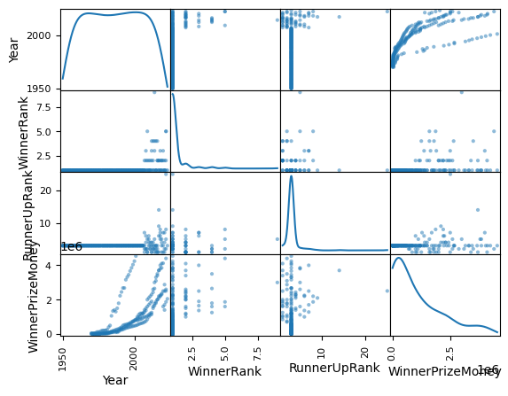

```python
#create correlation matrix
_ = pd.plotting.scatter_matrix(dfmerge,diagonal='kde')
```

### Findings

The only significant correlation in the dataset is the correlation between Winner Prize Money and Years which has a 0.718 correlation.

```python
prizeMoney = dfmerge.WinnerPrizeMoney
#make bins for the variable
bins = [0,50000, 100000, 300000,500000,1000000,2000000,3000000,4000000,5000000]
#puts the variable in bins
cats = pd.cut(prizeMoney, bins)
#get the count for each bins
cnts = pd.value_counts(cats)
#make df
dfPrizeMoney=DataFrame(cnts)
dfPrizeMoney
```

|  | WinnerPrizeMoney |
| --- | --- |
| (1000000, 2000000] | 39 |
| (500000, 1000000] | 35 |
| (0, 50000] | 32 |
| (100000, 300000] | 27 |
| (2000000, 3000000] | 23 |
| (300000, 500000] | 19 |
| (50000, 100000] | 14 |
| (3000000, 4000000] | 14 |
| (4000000, 5000000] | 6 |

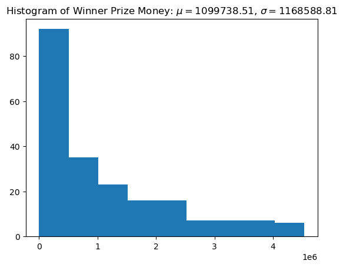

```python
plt.hist(dfmerge.WinnerPrizeMoney, 9)
mn = str(round(dfmerge.WinnerPrizeMoney.mean(),2))
sd = str(round(dfmerge.WinnerPrizeMoney.std(),2))
plt.title(f'Histogram of Winner Prize Money: $\mu= {mn}$, $\sigma={sd}$')
plt.savefig('WinnerPrizeMoneyHist.png')
plt.show()
```

### Findings

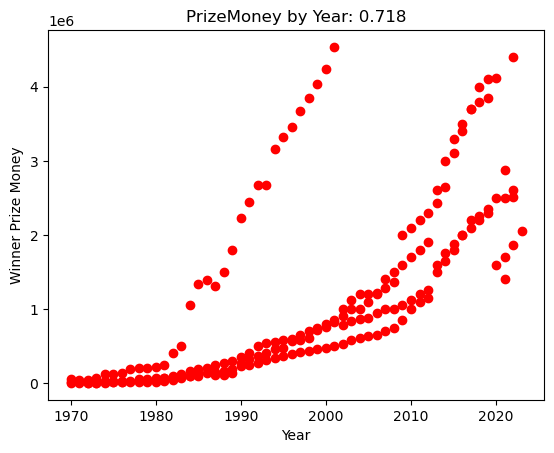

```python
#make scatterplot between Prize Money and Year
plt.scatter(dfmerge.Year,dfmerge.WinnerPrizeMoney,color='red')
PYcorr = round(dfmerge.WinnerPrizeMoney.corr(dfmerge.Year),3)
plt.title(f'PrizeMoney by Year: {PYcorr}')
plt.xlabel('Year')
plt.ylabel('Winner Prize Money')
plt.show()
```

### Findings

Winner Prize Money had a strong positive correlation with Years meaning that there was a significant yearly increase in prize money for grand slam tournaments from 1970-2023.

```python
#group prize money by tournament
prizeGroup = dfmerge.WinnerPrizeMoney.groupby(dfmerge.Tournament)
prizeGroup
#print mean and median groups
print(f"Mean of Each {prizeGroup.mean()}")
print(f"Median of Each {prizeGroup.median()}")
```

```
Mean of Each Tournament
Australian Open    1.200013e+06
French Open        1.521030e+06
U.S. Open          1.050698e+06
Wimbledon          6.219824e+05
Name: WinnerPrizeMoney, dtype: float64
Median of Each Tournament
Australian Open     615000.0
French Open        1303800.0
U.S. Open           600000.0
Wimbledon           378750.0
Name: WinnerPrizeMoney, dtype: float64
```

### Findings

```python
NatCnts = dfmerge.WinnerNationality.value_counts()
NatCnts
```

```
Australian        67
American          65
Spanish           33
Swedish           26
Swiss             23
Serbian           22
Czechoslovakia     8
German             7
Argentine          6
Russian            5
Czech              4
British            3
Brazilian          3
Czechoslovak       3
Italian            3
Romanian           2
Croatian           2
Austrian           2
peruvian           2
Mexican            1
Dutch              1
Ecuadorian         1
French             1
Name: WinnerNationality, dtype: int64
```

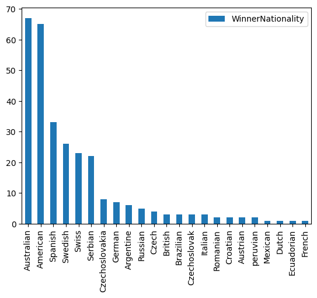

```python
dfNatCnts=DataFrame(dfmerge.WinnerNationality.value_counts())
dfNatCnts
dfNatCnts.plot(kind='bar')
```

```python
#Crosstab for Nationality by Surface
NatbySurf = pd.crosstab(dfmerge.WinnerNationality, dfmerge.Surface)
#print counts in order for Clay
NatbySurf.iloc[:,0].sort_values()
```

```
WinnerNationality
peruvian           0
Mexican            0
German             0
British            0
Croatian           0
Dutch              0
Russian            1
Romanian           1
French             1
Ecuadorian         1
Austrian           1
Czechoslovak       2
Swiss              2
Czech              2
Argentine          2
Serbian            2
Brazilian          3
Italian            3
Czechoslovakia     3
American           7
Australian        10
Swedish           10
Spanish           22
Name: Clay, dtype: int64
```

### Findings

Spain has by far the most grand slanm wins on clay by more than double the next country.

```python
#print counts in order for DecoTurf-outdoors
NatbySurf.iloc[:,1].sort_values()
```

```
WinnerNationality
Ecuadorian         0
Italian            0
French             0
Dutch              0
Czechoslovak       0
Czech              0
peruvian           0
Brazilian          0
British            1
Austrian           1
German             1
Mexican            1
Romanian           1
Croatian           1
Argentine          2
Russian            2
Czechoslovakia     3
Serbian            3
Swedish            3
Swiss              6
Spanish            6
Australian        18
American          24
Name: DecoTurf - outdoors, dtype: int64
```

### Findings

Americans are the most successful on DecoTurf-outdoors with 24 wins, and Australians are a close second at 18, while the next closest is at 6 wins.

```python
#print counts in order for Grass/Outdoor
NatbySurf.iloc[:,2].sort_values()
```

```
WinnerNationality
Ecuadorian         0
Argentine          0
Russian            0
Austrian           0
Brazilian          0
Romanian           0
Mexican            0
Italian            0
French             0
Czechoslovakia     0
peruvian           1
Czechoslovak       1
Czech              1
Croatian           1
Dutch              1
British            2
Spanish            3
German             4
Serbian            7
Swedish            7
Swiss              8
Australian        16
American          20
Name: Grass / Outdoor, dtype: int64
```

### Findings

```python
#print counts in order for Plexicushion Prestige
NatbySurf.iloc[:,3].sort_values()
```

```
WinnerNationality
Ecuadorian         0
Romanian           0
Mexican            0
Austrian           0
Brazilian          0
British            0
Croatian           0
Italian            0
Czechoslovak       0
French             0
Dutch              0
peruvian           1
Czech              1
Czechoslovakia     2
German             2
Argentine          2
Russian            2
Spanish            2
Swedish            6
Swiss              7
Serbian           10
American          14
Australian        23
Name: Plexicushion Prestige, dtype: int64
```

### Findings

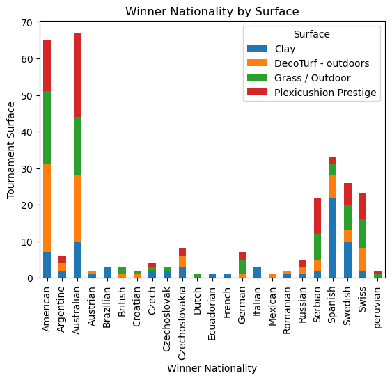

```python
#creating a stacked bar chart
NatbySurf.plot(kind='bar', stacked = True)
plt.xlabel('Winner Nationality')
plt.ylabel('Tournament Surface')
plt.title('Winner Nationality by Surface')
plt.show()
```

[output not shown]

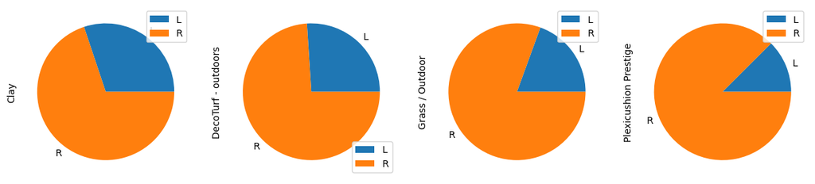

```python
#create crosstab between DomHand and Surface
DombyTour = DataFrame(pd.crosstab(dfmerge.WinnerDominantHand,dfmerge.Surface))
#create pie chart
DombyTour.plot.pie(subplots=True,figsize=[15,4])
```

### Findings

Right Hand Dominant Players are favored in all surfaces. However, left hand dominant players have the best chance to win on Clay, followed by DecoTurf-outdoors.